# POL 478 - Homework #8

1. Start a new `Rmd` document by going to `File-->New File-->R Markdown-->OK`. Save this document under the name `yourname_hw8.Rmd`. Delete the template Rmarkdown text and chunks (everything starting with ##R Markdown).
2. Make a new code chunk (`CTRL`+`Alt`+`I` on Windows, `Cmd` + `Option` + `I` on a Mac). In that chuck, load `tidyverse`, `magrittr`, and `lubridate` libraries, and the `covid_daily` dataset from the `classdata` package.
3. Give a visual breakdown of the number of Covid-19 deaths by month. Describe the results.
4. Introduce a variable `weekday` into the dataset.
   1. Make a visualization of Covid-19 cases by weekday. What day of the week is associated with the most cases? Why do you think that is?
   2. Make a visualization of Covid-19 deaths by weekday. What is the most deadly week of the day?
5. Suppose my hypothesis is that Covid-19 cases spike in the aftermath of large gatherings, such as the start of classes at schools with in-person classes, football games with in-person fans, etc. To test this, I decided to make a visual of Covid-19 cases (7-day rolling averages) for Iowa’s Johnson county, which is the home to the University of Iowa (U of I) and the state’s most popular football team, the Hawkeyes. I also made similar visualizations for the entire state of Iowa, and the United States.

   The graphs I made are presented below. Do these graphs provide support for my hypothesis, i.e. is there a spike in Covid-19 cases that we can attribute to the start of in-person classes and to the first home game of the favorite team? Why or why not? Please explain in detail how the visualizations support of fail to support the hypothesis.

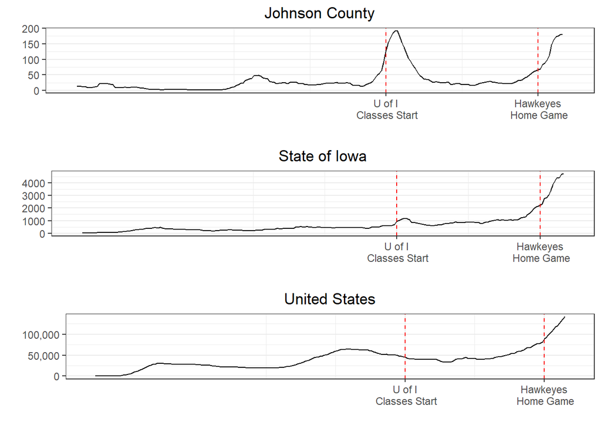

6. Replicate the above plots as closely as you can.
7. Knit the RMarkdown file (press the “Knit” button above) and read through the corresponding html file.

For the submission: submit your solution in an R Markdown file and (just for insurance) submit the corresponding html file with it.